# DSCI 100 - Introduction to Data Science

## Recap of the course content

[figure not shown]

*Photos/Images by #WOCinTech/#WOCinTech Chat ([CC-BY](https://creativecommons.org/licenses/by/2.0/))*

# Housekeeping

- Final exam: Thursday, Apr 23, 3:30 pm (Location: IRC 1)
- Prep for the final exam (sample of questions) and info will be posted this week
- Final exam info: expect about 45 questions in total, 110 minutes + 10 minutes for technical troubleshooting = 120 minutes in total
- Question types: multiple choice, true/false, short answer, fill in the blanks

## Week 1: What *is* data science?

**Data science** is the use of *reproducible* and *auditable* processes to obtain value (i.e., insight) from data.

**Data science workflow:**

[figure not shown]

## Week 2: Loading/importing data

- 4 most common ways to do this in Data Science
  1. **read in a text file with data in a spreadsheet format**
  2. **read from a database (e.g., SQLite, PostgreSQL)**
  3. scrape data from the web (optional bonus material)
  4. use a web API (Application Programming Interface) to read data from a website (not covered in DSCI100)

## Different ways to locate a file / dataset

**Local (on your computer)**

- An *absolute* path locates a file with respect to the "root" folder on a computer
  - starts with `/`

    e.g. `/home/instructor/documents/timesheet.xlsx`
- A *relative* path locates a file relative to your *working directory*
  - doesn't start with `/`

    e.g. `documents/timesheet.xlsx`  
    (where working directory is `/home/instructor/`)

**Remote (on the web)**

via "URL" that starts with `http://` or `https://`

```python
# Loading the data into Python (example):
df = pd.read_csv(my_url, skiprows=24, sep='\s+')
```

## Week 3: Data wrangling/tidying

## What is Tidy Data?

[figure not shown]

## Tools for tidying and wrangling data

- `Pandas` library functions
  - `[]` & `loc[]`
  - `assign`
  - `groupby` & `agg`
  - `melt` & `pivot`
  - `apply`

## Week 4: Data visualization

### Designing a visualization: ask a question, then answer it

The purpose of a visualization is to *answer a question* about a dataset of interest (usually this dataset contains results of a given data analysis or model).

Visualizations alone (w/o analysis applied to data) can help us answer two types of questions:

- **descriptive:** summarizes the data set without interpretation to describe some characteristics (e.g., report a fact).
- **exploratory:** are there patterns, trends, or relationships within a single data set? Often used to propose hypotheses for future study (discovery of ideas and thoughts)

### Creating visualizations in Python

- use `altair` package. There are three key aspects of plots in `altair`:
  1. `alt.Chart` creates a base chart and specifies which data to use.
  2. `mark_*` specifies which graphical marks to use when displaying the data.
  3. `encode` indicates how data frame columns should be encoded to visual channels (x, y, colours, etc.).
- All aspects of our chart will be chained using the dot notation:

```
alt.Chart(df).mark_circle().encode(
    x='column1',
    y='column2',
)
```

### Types of plots:

- **Scatter Plots**: to visualize the relationship between two quantitative variables (`mark_circle`)
- **Line Plots**: to visualize trends with respect to an independent quantity (`mark_line`)
- **Bar Plots**: to visualize the comparison of amounts (`mark_bar`)
- **Histograms**: to visualize the distribution of a single quantitative variable: (`mark_bar` plus `y='count()'`)

## Week 5: Version control

- **Version control:** the process of keeping a record of changes to documents, including when the changes were made and who made them
- lets you view earlier versions and revert changes
- facilitates resolving conflicting edits

### Git and GitHub

Two major tools for version control:

**Git:**

- keeps track of files in a **repository** (a folder that you tell Git to pay attention to)
- responsible for keeping track of changes, sharing files with others, handling conflict resolution, etc
- Git runs on your (and your teammates') machine

**GitHub:**

- a service that hosts your repository in the cloud
- helps manage permissions (who can view your project, who can edit it)
- provides tools for project-specific communication (organized into *issues*)
- can be used to build and host websites/blogs

### Key version control concepts and commands

[figure not shown]

### Key version control concepts and commands

[figure not shown]

## Weeks 6 & 7: Classification using K-Nearest Neighbours

### K-nearest neighbours classification

Supervised learning method with a goal to predict the **categorical value** (label / class) for a new observation using the K closest points from the dataset.

1. *Standardize:* shift and scale each variable in the dataset so that the average of each variable is 0 and the standard deviation is 1.
2. Compute the distance between the new observation and each observation in the standardized *training set*
3. Choose K data points with the shortest distances as the "neighbours"
4. Classify the new observation based on majority vote.

```python
# Example of the Python script for k-NN classification

# use pipeline (to line up the commands):
from sklearn.pipeline import make_pipeline

# standardize the  variables in X:
preprocessor = make_column_transformer(
    (StandardScaler(), ["Area", "Smoothness"]),
)
# set K in K-NN method:
knn = KNeighborsClassifier(n_neighbors=3)

# call pipleine in the order of standardize and then apply K-NN:
pipe = make_pipeline(preprocessor, knn)

# apply K-NN on the training data (here two variables for X, and
# categorical data in Y):
pipe.fit(X=cancer[["Area", "Smoothness"]], y=cancer["Class"])

# input the new data point and predict the class
new_observation = pd.DataFrame({"Area": [400], "Smoothness": [0.136]})
pipe.predict(new_observation)
```

## Evaluation

Is our model any good? How do we **evaluate** it?

### Accuracy

$$Accuracy = \dfrac{\#\; correct\; predictions}{\#\; total\; predictions}$$

### Precision and Recall (derived from the Confusion matrix)

$$ {Precision} = \dfrac{{\#\; correct\; positive\; predictions}}{{\#\; total\; positive\; predictions}} \quad\quad\quad \quad {Recall} = \dfrac{{\#\; correct\; positive\; predictions}}{{\#\; total\; truly\; positive\; observations}} $$

### Adding evaluation to the pipeline for building a classifier

1. Split our data into two subsets: *training data* and *testing data*.
2. Build the model & choose K using training data only (sometimes called tuning)
3. Compute performance metrics (accuracy, precision, recall, etc.) by predicting labels on testing data only

### Choosing K (or, "tuning'' the model)

Want to choose K to maximize accuracy.

**Cross-validation:**  
1. Choose some candidate values of K  
2. Split data into C folds. Use fold 1 as the **training data**, and all other folds as the **validation set**  
3. For each K, train the model using **training set only**  
4. Evaluate accuracy (and/or other metrics of performance) for each K using the **validation set only**  
5. Repeat from step 2 picking another fold (fold 2, fold 3, etc) for the training set until all folds are used as the training set.  
6. Pick the K that maximizes averaged accuracy across all validation datasets used above

```python
# Example of the Python script for k-NN classification with
# cross-validation

from sklearn.preprocessing import StandardScaler
from sklearn.compose import make_column_transformer
from sklearn.model_selection import cross_validate

# standardize the variables in X-data
cancer_preprocessor = make_column_transformer(
    (StandardScaler(), ["Smoothness", "Concavity"]),
)

# apply k-NN classifier with 5-fold cross-validation
knn = KNeighborsClassifier(n_neighbors=3)
cancer_pipe = make_pipeline(cancer_preprocessor, knn)
X = cancer_train[["Smoothness", "Concavity"]]
y = cancer_train["Class"]
cv_5_df = pd.DataFrame(
    cross_validate(
        estimator=cancer_pipe,
        cv=5,
        X=X,
        y=y
    )
)
```

## Overview of the tuning and evaluation

[figure not shown]

## Week 8: Regression with k-nearest neighbours

### K-nearest neighbours regression

Supervised learning method with a goal to predict the **quantitative** (continuous, numerical) value for a new observation using the K closest points from the dataset.

1. *Standardize:* shift and scale each variable in the dataset so that the average of each variable is 0 and the standard deviation is 1.
2. Compute the distance between the new observation and each observation in the standardized *training set*
3. Choose K data points with the shortest distances as the "neighbours"
4. Predict the new observation based on the average values of the neighbours

## Evaluation

Is our model any good? How do we **evaluate** it?

*Root Mean Squared Prediction Error* (RMSPE):

$$RMSPE = \sqrt{\frac{1}{n}\sum\limits_{i=1}^{n}(y_i - \hat{y_i})^2}$$

- $n$ is the number of observations in the testing dataset

- $y_i$ is the observed value for the $i^\text{th}$ test observation

- $\hat{y_i}$ is the forcasted/predicted value for the $i^\text{th}$ test observation

## Overview of the tuning and evaluation

Same process as with k-NN classification, but using RMSE as the evaluation metric and not the accuracy

[figure not shown]

```python
# Example of the Python script for k-NN regression with
# cross-validation (5 folds here)

# import the K-NN regression model
from sklearn.neighbors import KNeighborsRegressor

# preprocess the data, make the pipeline
sacr_preprocessor = make_column_transformer((StandardScaler(), ["sqft"]))
sacr_pipeline = make_pipeline(sacr_preprocessor, KNeighborsRegressor())

# create the 5-fold GridSearchCV object
param_grid = {
    "kneighborsregressor__n_neighbors": range(1, 201, 3),
}
sacr_gridsearch = GridSearchCV(
    estimator=sacr_pipeline,
    param_grid=param_grid,
    cv=5,
    scoring="neg_root_mean_squared_error",
)
```

## Underfitting & Overfitting

General pattern for the K-NN methods (classification and regression): small K overfits, large K underfits

## Week 9: Linear regression

### Linear Regression

Supervised learning method with a goal to predict the **quantitative** (continuous, numerical) value for a new observation by fitting a straight line to the dataset (scatter plot where the predictor variable is on x-axis and response variable is on y-axis).

The equation for a straight line is: $Y = \beta_0 + \beta_1X$

- $\beta_0$ is the y-intercept of the line (the value where the line cuts the y-axis)
- $\beta_1$ is the slope of the line

Finding the "line of best fit" = finding the values of $\beta_0, \beta_1$ that result in the lowest RMSE!

[figure not shown]

```python
# Example of the Python script for linear regression

# create training data
sacramento_train, sacramento_test = train_test_split(
    house_data, train_size=0.6, random_state=1234)
X_train = sacramento_train[["sqft"]]
y_train = sacramento_train[["price"]]

# create the model specification and recipe
lm = LinearRegression()

# put it together in a workflow and fit a line
lm.fit(X_train, y_train)

# view 𝛽0 (intercept), and 𝛽1(slope)
pd.DataFrame({"slope": lm.coef_[0], "intercept": lm.intercept_})
```

### Multiple Linear Regression

This is the regression with more than one predictor.

We we fit a *hyperplane* (e.g. for $m$ predictors): $$Y = \beta_0 + \beta_1 X_1 + \beta_2 X_2 + \dots + \beta_m X_m$$

- $\beta_0$: intercept
- $\beta_i$: slope for variable $i=1, \dots, m$

[figure not shown]

## Week 10: Clustering

### Clustering

- Unsupervised learning task of separating data into groups by similarity
- Useful for exploratory analysis, developing new questions, and subgrouping to improve predictive models

## K-Means clustering algorithm

K-Means is an algorithm for separating data into K clusters

[figure not shown]

### K-Means clustering summary

1. **Choose K:** number of clusters to group the observations
2. **Initialize:** assign data to K clusters randomly
3. **Iterate:**
   1. **Update Center:** calculate average coordinates of each cluster
   2. **Update Label:** re-assign the data to the closest cluster center
   3. **Check:** If no labels changed, terminate.

```python
# Example of the Python script for Kmeans clustering
from sklearn.preprocessing import StandardScaler
from sklearn.compose import make_column_transformer
from sklearn import set_config
from sklearn.cluster import KMeans
from sklearn.pipeline import make_pipeline

# Output dataframes instead of arrays
set_config(transform_output="pandas")

# Apply standardization of variables
preprocessor = make_column_transformer(
    (StandardScaler(), ["bill_length_mm", "flipper_length_mm"]),
    verbose_feature_names_out=False,
)

# set the number of clusters
kmeans = KMeans(n_clusters=3)

# apply clustering
penguin_clust = make_pipeline(preprocessor, kmeans)
penguin_clust.fit(penguins)
```

### What is a "good" cluster?

[figure not shown]

A good cluster of data is "tightly packed" around its centroid, i.e., has a small **within-cluster sum-of-squared-distances (WSSD)**.

WSSD = Add up the squared **distance** between each **point** and the **center/mean** of the cluster.

### Choosing K (number of clusters)

- If **K is too small**, the centers are bad representatives of the clusters, and **total WSSD is high**
- If **K is too large**, the clusters get "subdivided", leading to a **slow decrease in total WSSD**

**Pick K where the "elbow" occurs!** (if there is no obvious elbow, the data may not be very strongly clustered)

[figure not shown]

### Random Initialization

- K-means is an *iterative* algorithm
- It will find different final clusterings depending on initialization
- Use `random_state` and the `n_init` argument in scikit learns's implementation of the algorithm so that you run the model multiple times, each time with different initialiation (position of centroids)

`KMeans(n_clusters, random_state, **n_init**, ...)`

```python
# Example of Python script for choosing k with the elbow method
# with 10 different random initializations

# set k in the range 1 to 10
ks = range(1, 10)
wssds = [
    make_pipeline(
    	preprocessor,
    	KMeans(n_clusters=k, random state, n_init=10)
    ).fit(penguins)[1].inertia_
    for k in ks
]

penguin_clust_ks = pd.DataFrame({
    "k": ks,
    "wssd": wssds,
})

# Produce the elbow plot
elbow_plot = alt.Chart(penguin_clust_ks).mark_line(point=True).encode(
    x=alt.X("k").title("Number of clusters"),
    y=alt.Y("wssd").title("Total within-cluster sum of squares"),
)
```

## Weeks 11 & 12: Inference

**Statistical inference** is the process of using a *sample* to make conclusions about a wider *population* the sample came from.

- **Population:** collection of all possible observations + their frequency/count (e.g. the widths of the entire population of sea stars)
- **Sample:** a randomly selected subset of observations (randomly picked 50 sea stars and record their widths)
- **Sample estimate:** something I compute using my sample (e.g. the mean width of the sea stars *in my sample*)

### Estimation

A particular inferential problem where we try to *estimate a quantitative property* of the population.

This quantitative property is called a **population parameter** (e.g. mean width of the sea stars in the whole population of sea stars).

### Sampling distribution

This is the *distribution* of estimates you get by taking many samples *of a fixed sample size* (e.g. a distibution of the mean width of the sea stars from many samples)

### Bootstraping

In practice, we only have one sample, not the full population. Bootstrapping approximates the sampling distribution by:

- Repeatedly resampling with replacement from the observed sample
- Computing the statistic (e.g., mean) for each resample
- Using these values to form the bootstrap distribution

This distribution approximates the true sampling distribution and lets us estimate uncertainty.

*Bootstrapping = resample from your sample to mimic repeated sampling from the population.*

## Using the bootstrap to calculate a plausible range of the mean

- Use the bootstrap distribution to calculate the plausible range of values for the population parameter:
- *95% confidence interval*: 95% of the means from our bootstrap resampling fell in this interval.
- Report **both** our sample point estimate and the plausible range where we expect our true population quantity to fall.

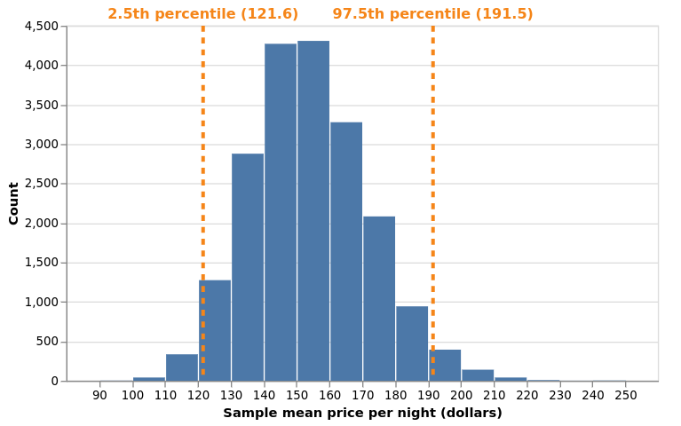

```python
# An example of Python script taking 20,000 bootstrap samples from
# the original sample and calulating the mean for each sample

import pandas as pd
import numpy as np

# setting the random seed to 155 (generator of random numbers;
# any seed number can be selected) via numpy to make
# the results reproducible. This means that if we rerun
# the code we would get the same random points in the samples
np.random.seed(155)

# creating 20,000 bootstrap samples
boot20000 = pd.concat([
    one_sample.sample(frac=1, replace=True).assign(replicate=n)
    for n in range(20_000)
])

# calculate point estimates of the mean for our 20,000 bootstrap samples

boot20000_means = (
    boot20000
    .groupby("replicate")
    ["price"]
    .mean()
    .reset_index()
    .rename(columns={"price": "mean_price"})
)
```